# Prob 5, CP 2: Regressão Logística e match

## Dados

Temos dados descrevendo 5000 encontros relâmpagos envolvendo 310 jovens americanos. Os dados originais foram coletados por professores da Columbia Business School. Os participantes tinham vários encontros de 4 minutos por noite. Após cada um, preenchiam fichas avaliando aqueles com quem se encontraram. Cada linha nos dados representa um desses encontros. As informações na ficha representavam dados pessoais como idade e gênero, e opiniões do participante sobre a pessoa com quem ele se encontrou, além de avaliações sobre um possível relacionamento entre eles. Nesse checkpoint há uma coluna a mais nos dados, chamada `dec`, que diz se o participante 1 gostaria de se encontrar novamente com o participante 2 dado como foi o encontro relâmpago.

```r
dados %>%
  na.omit(dec, like, fun, attr, shar, sinc, intel) -> dados

glm(dec ~ like + fun + attr + shar + sinc + intel,
      data = dados,
      family = "binomial") -> bm

tidy(bm, conf.int = TRUE) %>%
  select(-statistic, -p.value)
```

```
## # A tibble: 7 x 5
##   term        estimate std.error conf.low conf.high
##   <chr>          <dbl>     <dbl>    <dbl>     <dbl>
## 1 (Intercept)  -6.46      0.430   -7.32     -5.63
## 2 like          0.753     0.0679   0.623     0.889
## 3 fun           0.0691    0.0507  -0.0303    0.169
## 4 attr          0.367     0.0492   0.272     0.465
## 5 shar          0.125     0.0393   0.0479    0.202
## 6 sinc         -0.136     0.0528  -0.241    -0.0332
## 7 intel        -0.140     0.0586  -0.256    -0.0261
```

```r
tidy(bm, conf.int = TRUE, exponentiate = TRUE) %>%
  select(-statistic, -p.value)
```

```
## # A tibble: 7 x 5
##   term        estimate std.error conf.low conf.high
##   <chr>          <dbl>     <dbl>    <dbl>     <dbl>
## 1 (Intercept)  0.00157    0.430  0.000662   0.00357
## 2 like         2.12       0.0679 1.86       2.43
## 3 fun          1.07       0.0507 0.970      1.18
## 4 attr         1.44       0.0492 1.31       1.59
## 5 shar         1.13       0.0393 1.05       1.22
## 6 sinc         0.872      0.0528 0.786      0.967
## 7 intel        0.869      0.0586 0.774      0.974
```

```r
glance(bm)
```

```
## # A tibble: 1 x 7
##   null.deviance df.null logLik   AIC   BIC deviance df.residual
##           <dbl>   <int>  <dbl> <dbl> <dbl>    <dbl>       <int>
## 1         2219.    1621  -771. 1556. 1593.    1542.        1615
```

```r
pR2(bm)
```

```
##           llh       llhNull            G2      McFadden          r2ML
##  -770.8410637 -1109.3187884   676.9554495     0.3051221     0.3412153
##          r2CU
##     0.4577959
```

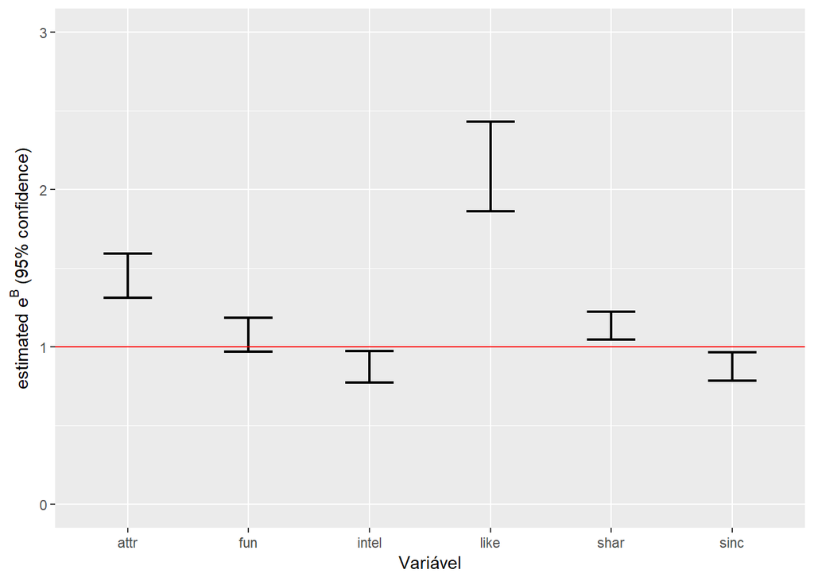

```r
tidy(bm, conf.int = TRUE, conf.level = 0.95, exponentiate = TRUE) %>%
  filter(term != "(Intercept)") %>%
  ggplot(aes(term, estimate, ymin = conf.low, ymax = conf.high)) +
  geom_errorbar(size = 0.8, width= 0.4) +
  geom_hline(yintercept = 1, colour = "red") +
  labs(x = "Variável",
       y = expression(paste("estimated ", 'e'^{'B'}," (95% confidence)"))) +
  ylim(0,3)
```

Após gerar o modelo de regressão logística, vamos responder às perguntas.

## Dentre os fatores que podem ter efeito no match, quais fatores têm efeito significativo na chance de p1 decidir se encontrar novamente com p2?

fun (quão divertido p1 achou p2) não possui significância para explicar a variável dec porque cruza o limiar. Já intel (quão inteligente p1 achou p2) e sinc (quão sincero p1 achou p2) têm um efeito negativo no match, enquanto attr (quão atraente p1 achou p2), like (quanto p1 gostou de p2) e shar (quanto p1 achou que compartilha interesses e hobbies com p2) têm efeitos positivos.

## Que fatores nos dados têm mais efeito na chance de um participante querer se encontrar novamente com outro?

Like é o fator que têm mais efeito nessa chance, porque seu intervalo de confiança se encontra mais distante de 1, no sentido crescente.